# Blue Beer’s Picasso

Karl J. Jurek, Travis R. Daun, Joe Jiang

1/7/2019

# Introduction

We wish to develop a strategy for the deployment of a new beer, Blue Beer’s Picasso. Blue Beer’s Picasso has higher than typical alcohol content (ABV= 0.06) while having a lower than typical bitterness rating (IBU = 30). Market research has shown that Millennials and iGen (>=21) prefer locally brewed beers, that have a high alcohol content but are not drawn to highly bitter beers. Blue Beer’s Picasso is looking to launch their brewery production in an area with fewer than 10 breweries in the state, has a supporting demographic, and prefers beers with Blue Beer’s ABV and IBU characteristics.

## 0. Preliminary code set-up.

- This code loads the required packages used in the data analysis and visualization.
- For the interactive maps used the area projections for the US states need to be retransformed from what is supplied in the SDdata package for US States.
- A state crosswalk table was created to map state names to abbreviations for use in the map functions called throughout the code.
- The codebook for this project provides greater technical specifics on packages, transformations, and mapping.

```r
#Load required packages
library(dplyr)
```

```r
library(tidyr)
library(ggplot2)
library(tidyverse)
library(spData) # contains datasets used in this project
library(sf)     # for handling spatial (vector) data
library(tmap)   # map making package
library(grid)   # to re-arrange maps

#Create map geometry for US
us_states2163 = st_transform(us_states, 2163)

#Generate cross reference of state names (and DC) and abbreviations
st_crosswalk <- tibble(state = state.name) %>%
  bind_cols(tibble(abb = state.abb)) %>%
  bind_rows(tibble(state = "District of Columbia", abb = "DC"))
colnames(st_crosswalk) <- c("State", "Abb")
```

## 1. How many breweries are present in each state?

- This code first loads the two datasets into dataframes.
- Data tidying is done to remove extra whitespace in the state abbreviations and then implicit column names are given to ensure consistency throughout the analysis.
- The state crosswalk of state names and abbreviations are joined to the breweries data frame.

```r
#Read in csv data files Beers.csv and Breweries.csv
beers <- read.csv("Beers.csv")
breweries <- read.csv("Breweries.csv")

str(breweries)
```

```
## 'data.frame':    558 obs. of  4 variables:
##  $ Brew_ID: int  1 2 3 4 5 6 7 8 9 10 ...
##  $ Name   : Factor w/ 551 levels "10 Barrel Brewing Company",..: 355 12 266 319 201 136 227 477 59 491 ...
##  $ City   : Factor w/ 384 levels "Abingdon","Abita Springs",..: 228 200 122 299 300 62 91 48 152 136 ...
##  $ State  : Factor w/ 51 levels " AK"," AL"," AR",..: 24 18 20 5 5 41 6 23 23 23 ...
```

```r
str(beers)
```

```
## 'data.frame':    2410 obs. of  7 variables:
##  $ Name      : Factor w/ 2305 levels "#001 Golden Amber Lager",..: 1638 577 1704 1842 1819 268 1160 758 1093 486 ...
##  $ Beer_ID   : int  1436 2265 2264 2263 2262 2261 2260 2259 2258 2131 ...
##  $ ABV       : num  0.05 0.066 0.071 0.09 0.075 0.077 0.045 0.065 0.055 0.086 ...
##  $ IBU       : int  NA NA NA NA NA NA NA NA NA NA ...
##  $ Brewery_id: int  409 178 178 178 178 178 178 178 178 178 ...
##  $ Style     : Factor w/ 100 levels "","Abbey Single Ale",..: 19 18 16 12 16 80 18 22 18 12 ...
##  $ Ounces    : num  12 12 12 12 12 12 12 12 12 12 ...
```

```r
#Remove any whitespace in state abbreviations
breweries$State <- gsub("\\s+", "", breweries$State)
#Give known column names
colnames(breweries) <- c("Brew_ID", "Name", "City", "Abb")

#Join data frames so state name is available for use
breweries <- left_join(breweries, st_crosswalk, by = "Abb")
```

### Listing of number of breweries by state

- This code groups the breweries by state and then counts the number of breweries in each state. An output of the first 10 states and the respective number of breweries in those states is listed.

```r
#group and sumarizenumber of breweries by state
by_state <- breweries%>%group_by(State)%>%summarize('NumberOfBreweries' = n())
by_state
```

```
## # A tibble: 51 x 2
##    State                NumberOfBreweries
##    <chr>                            <int>
##  1 Alabama                              3
##  2 Alaska                               7
##  3 Arizona                             11
##  4 Arkansas                             2
##  5 California                          39
##  6 Colorado                            47
##  7 Connecticut                          8
##  8 Delaware                             2
##  9 District of Columbia                 1
## 10 Florida                             15
## # ... with 41 more rows
```

### Bar graph of number of breweries by state

- This code displays the 50 states and the District of Columbia in a bar graph with the number of breweries in each state displayed.

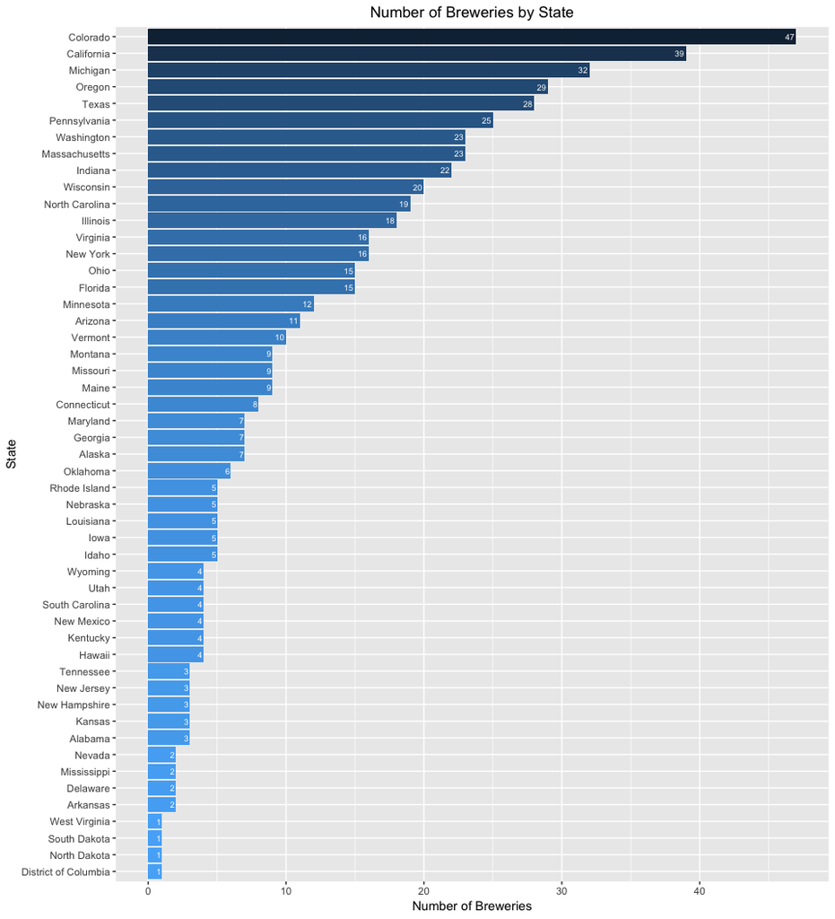

```r
#Plot number of breweries by State
ggplot(data = by_state, aes(x=reorder(State, NumberOfBreweries), y=NumberOfBreweries, fill=-NumberOfBreweries)) +
  geom_bar(stat="identity") +
  geom_text(aes(label=NumberOfBreweries), hjust=1.2, vjust=0.5, color="white", size=2.5) +
  ggtitle("Number of Breweries by State") +
  theme(plot.title = element_text(hjust = 0.5)) +
  labs(y="Number of Breweries", x="State", fill="NumberOfBreweries") +
  coord_flip() +
  guides(fill=FALSE)
```

### Static map of number of breweries by state

- This code maps the number of breweries in each state onto a color coded map of the United States (Higher number of breweries equates to a darker color). Note that we do not display Hawaii and Alaska because they are beyond the scope of our expansion project.

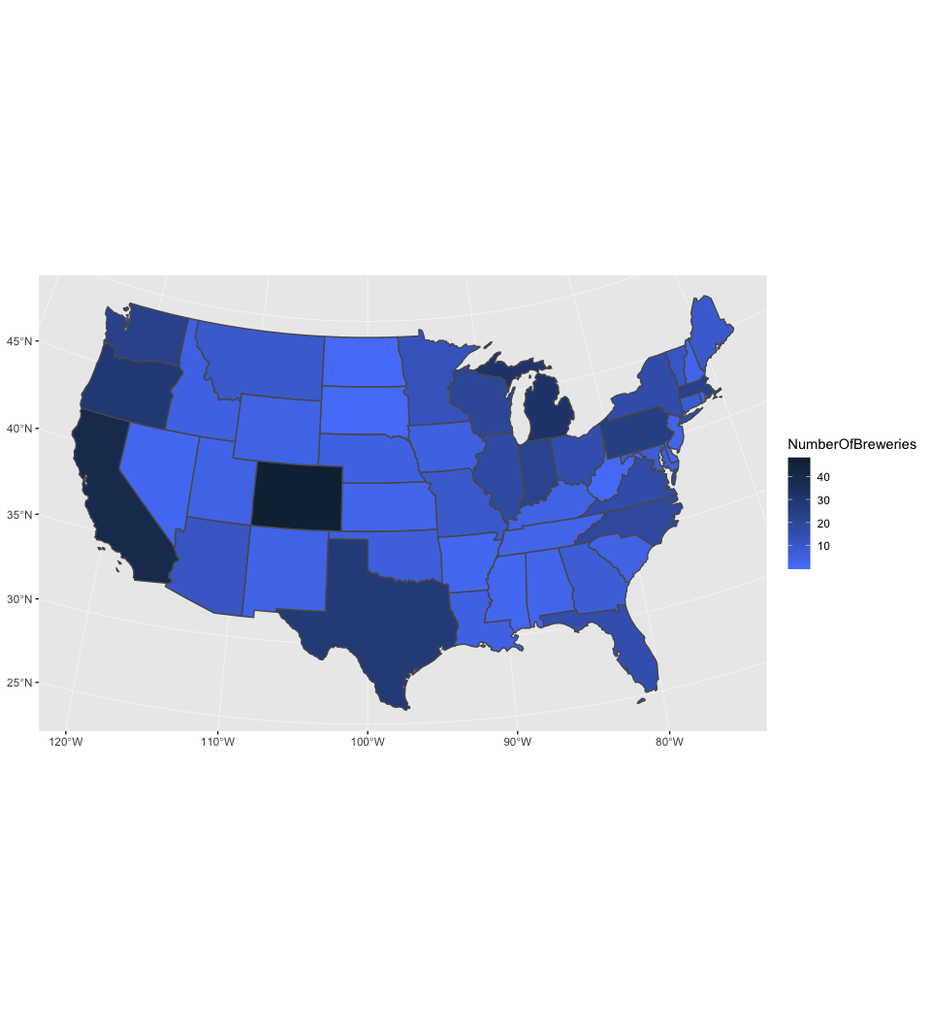

```r
#Create a static map of US based on number of breweries
colnames(by_state) <- c("NAME", "NumberOfBreweries")
state_map_and_data <- inner_join(us_states2163, by_state)
ggplot(state_map_and_data) +
  geom_sf(aes(fill = NumberOfBreweries))+
  scale_fill_gradient(low= "#5681F7", high ="#132B43")
```

### Interactive map of number of breweries by state (click on state desired)

- This code maps the number of breweries in each state onto an interactive color coded map of the United States (Higher number of breweries equates to a darker color). If you hover over the state the state name will be displayed. Clicking on the state will display the number of breweries in that state. Note that we do not display Hawaii and Alaska because they are beyond the scope of our expansion project.

```r
#Create interactive map of number of breweries
tmap_mode("view")
```

```
## tmap mode set to interactive viewing
```

```r
tm_shape(state_map_and_data) +
  tm_polygons("NumberOfBreweries", id="NAME", palette = "Blues")
```

[interactive chart not shown]

## 2a. Merge beer data with the breweries data.

- This code merges the two data frames on a common variable that signifies the brewery identifier.
- Implicit column names are given to the new merged dataframe to ensure consistency throughout the analysis.

```r
#merge beer data with brewery data
breweriesdf <- merge(breweries, beers, by.x = "Brew_ID", by.y ="Brewery_id")

colnames(breweriesdf) <- c("Brewery_ID", "Brewery Name", "City", "Abb", "State", "Beer Name", "Beer_ID", "ABV", "IBU", "Style",
                           "Ounces")
```

### 2b. Print the first 6 observations to check the merged file.

```r
head(breweriesdf, 6)
```

```
##   Brewery_ID       Brewery Name        City Abb     State     Beer Name
## 1          1 NorthGate Brewing  Minneapolis  MN Minnesota       Pumpion
## 2          1 NorthGate Brewing  Minneapolis  MN Minnesota    Stronghold
## 3          1 NorthGate Brewing  Minneapolis  MN Minnesota   Parapet ESB
## 4          1 NorthGate Brewing  Minneapolis  MN Minnesota  Get Together
## 5          1 NorthGate Brewing  Minneapolis  MN Minnesota Maggie's Leap
## 6          1 NorthGate Brewing  Minneapolis  MN Minnesota    Wall's End
##   Beer_ID   ABV IBU                               Style Ounces
## 1    2689 0.060  38                         Pumpkin Ale     16
## 2    2688 0.060  25                     American Porter     16
## 3    2687 0.056  47 Extra Special / Strong Bitter (ESB)     16
## 4    2692 0.045  50                        American IPA     16
## 5    2691 0.049  26                  Milk / Sweet Stout     16
## 6    2690 0.048  19                   English Brown Ale     16
```

### 2b. Print the last six observations to check the merged file.

```r
tail(breweriesdf, 6)
```

```
##      Brewery_ID                  Brewery Name          City Abb      State
## 2405        556         Ukiah Brewing Company         Ukiah  CA California
## 2406        557       Butternuts Beer and Ale Garrattsville  NY   New York
## 2407        557       Butternuts Beer and Ale Garrattsville  NY   New York
## 2408        557       Butternuts Beer and Ale Garrattsville  NY   New York
## 2409        557       Butternuts Beer and Ale Garrattsville  NY   New York
## 2410        558 Sleeping Lady Brewing Company     Anchorage  AK     Alaska
##                      Beer Name Beer_ID   ABV IBU                   Style
## 2405             Pilsner Ukiah      98 0.055  NA         German Pilsener
## 2406         Porkslap Pale Ale      49 0.043  NA American Pale Ale (APA)
## 2407           Snapperhead IPA      51 0.068  NA            American IPA
## 2408         Moo Thunder Stout      50 0.049  NA      Milk / Sweet Stout
## 2409  Heinnieweisse Weissebier      52 0.049  NA              Hefeweizen
## 2410 Urban Wilderness Pale Ale      30 0.049  NA        English Pale Ale
##      Ounces
## 2405     12
## 2406     12
## 2407     12
## 2408     12
## 2409     12
## 2410     12
```

## 3. Report the number of NA’s in each column.

```r
#Count the NAs in each column
colSums(is.na(breweriesdf))
```

```
##   Brewery_ID Brewery Name         City          Abb        State
##            0            0            0            0            0
##    Beer Name      Beer_ID          ABV          IBU        Style
##            0            0           62         1005            0
##       Ounces
##            0
```

## 4a. Compute the median alcohol content and international bitterness unit for each state.

- This code groups the beers from each brewery by the state they are brewed in and then calculates the median alcohol content (ABV) and median bitterness (IBU) by state. This code omits any NA values from ABV or IBU when calculating the median values.
- The max and min median ABV and median IBU are then printed.
- The states with the highest median ABV, lowest median ABV, highest IBU, and lowest IBU are printed.

```r
#Median ABV and IBU by state
Medians <- breweriesdf%>%group_by(State)%>%summarise(Median_ABV = median(na.omit(ABV)),                                                      Median_IBU = median(na.omit(IBU)))

Medians%>%summarise(max = max(na.omit(Median_ABV)))
```

```
## # A tibble: 1 x 1
##      max
##    <dbl>
## 1 0.0625
```

```r
Medians%>%summarise(min = min(na.omit(Median_ABV)))
```

```
## # A tibble: 1 x 1
##     min
##   <dbl>
## 1  0.04
```

```r
Medians%>%summarise(max = max(na.omit(Median_IBU)))
```

```
## # A tibble: 1 x 1
##     max
##   <dbl>
## 1    61
```

```r
Medians%>%summarise(min = min(na.omit(Median_IBU)))
```

```
## # A tibble: 1 x 1
##     min
##   <dbl>
## 1    19
```

```r
head(arrange(Medians, desc(Median_ABV)),3)
```

```
## # A tibble: 3 x 3
##   State                Median_ABV Median_IBU
##   <chr>                     <dbl>      <dbl>
## 1 District of Columbia     0.0625       47.5
## 2 Kentucky                 0.0625       31.5
## 3 Michigan                 0.062        35
```

```r
tail(arrange(Medians, desc(Median_ABV)),2)
```

```
## # A tibble: 2 x 3
##   State      Median_ABV Median_IBU
##   <chr>           <dbl>      <dbl>
## 1 New Jersey      0.046       34.5
## 2 Utah            0.04        34
```

```r
head(arrange(Medians, desc(Median_IBU)),2)
```

```
## # A tibble: 2 x 3
##   State         Median_ABV Median_IBU
##   <chr>              <dbl>      <dbl>
## 1 Maine              0.051       61
## 2 West Virginia      0.062       57.5
```

```r
tail(arrange(Medians, desc(Median_IBU)),3)
```

```
## # A tibble: 3 x 3
##   State        Median_ABV Median_IBU
##   <chr>             <dbl>      <dbl>
## 1 Kansas            0.05          20
## 2 Wisconsin         0.052         19
## 3 South Dakota      0.06          NA
```

### 4b. Plot a bar chart to compare.

- This code prints a bar chart of the median ABV by state. The bars are filled with the median IBU.
- A bar chart of the median IBU by state is then created. These bars are filled with the median ABV.

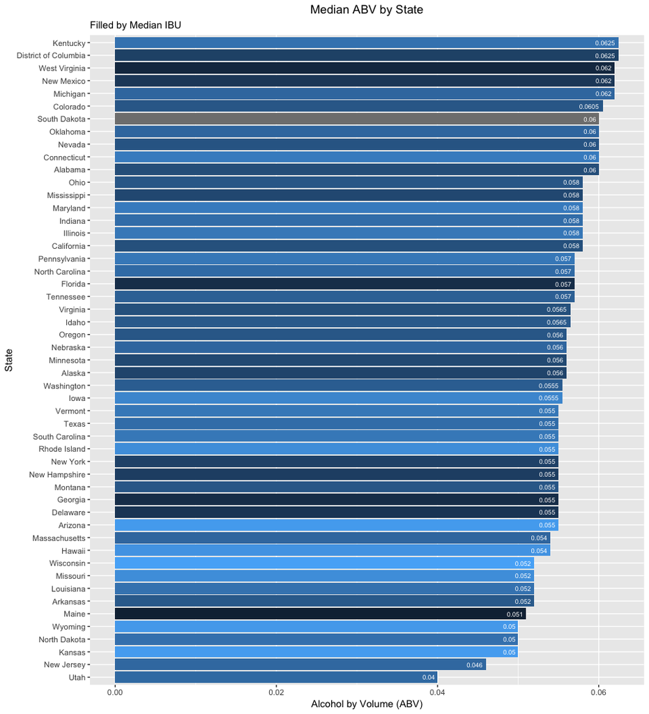

```r
ggplot(data = Medians, aes(x=reorder(State, Median_ABV), y=Median_ABV, fill=-Median_IBU )) +
  geom_bar(stat="identity") +
  geom_text(aes(label=Median_ABV), hjust=1.2, vjust=0.5, color="white", size=2.5) +
  ggtitle("Median ABV by State") +
  theme(plot.title = element_text(hjust = 0.5)) +
  labs(y="Alcohol by Volume (ABV)", x="State", subtitle="Filled by Median IBU") +
  coord_flip() +
  guides(fill=FALSE)
```

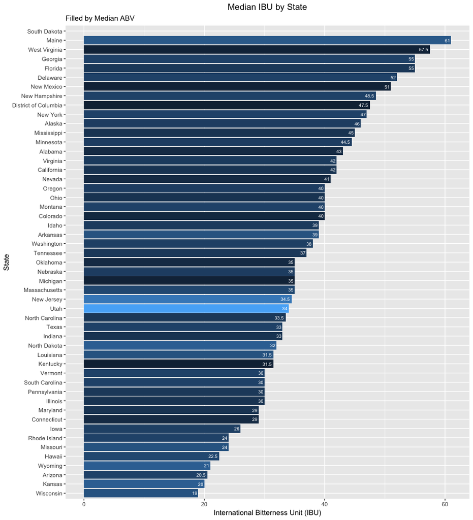

```r
ggplot(data = Medians, aes(x=reorder(State, Median_IBU), y=Median_IBU, fill=-Median_ABV )) +
  geom_bar(stat="identity") +
  geom_text(aes(label=Median_IBU), hjust=1.2, vjust=0.5, color="white", size=2.5) +
  ggtitle("Median IBU by State") +
  theme(plot.title = element_text(hjust = 0.5)) +
  labs(y="International Bitterness Unit (IBU)", x="State", subtitle="Filled by Median ABV") +
  coord_flip() +
  guides(fill=FALSE)
```

## 5a. Which state has the maximum alcoholic (ABV) beer?

*The states with the highest maximum alcoholic (ABV) beer are the District of Columbia and Kentucky with a median ABV of 0.0625.*

```r
head(arrange(Medians, desc(Median_ABV)),3)
```

```
## # A tibble: 3 x 3
##   State                Median_ABV Median_IBU
##   <chr>                     <dbl>      <dbl>
## 1 District of Columbia     0.0625       47.5
## 2 Kentucky                 0.0625       31.5
## 3 Michigan                 0.062        35
```

```r
tail(arrange(Medians, desc(Median_ABV)),2)
```

```
## # A tibble: 2 x 3
##   State      Median_ABV Median_IBU
##   <chr>           <dbl>      <dbl>
## 1 New Jersey      0.046       34.5
## 2 Utah            0.04        34
```

### 5b. Which state has the most bitter (IBU) beer?

*The state with the most bitter (IBU) beer is Maine with a median IBU of 61.*

```r
head(arrange(Medians, desc(Median_IBU)),2)
```

```
## # A tibble: 2 x 3
##   State         Median_ABV Median_IBU
##   <chr>              <dbl>      <dbl>
## 1 Maine              0.051       61
## 2 West Virginia      0.062       57.5
```

```r
tail(arrange(Medians, desc(Median_IBU)),3)
```

```
## # A tibble: 3 x 3
##   State        Median_ABV Median_IBU
##   <chr>             <dbl>      <dbl>
## 1 Kansas            0.05          20
## 2 Wisconsin         0.052         19
## 3 South Dakota      0.06          NA
```

### 5c. Interactive Dynamic Maps for ABV and IBU

- This code generates interactive maps for median ABV and median IBU. Hovering over the state displays the state name and clicking displays the ABV or IBU respectively.

```r
#For interactive mapping data
mapdata <- breweriesdf
str(mapdata)
```

```
## 'data.frame':    2410 obs. of  11 variables:
##  $ Brewery_ID  : int  1 1 1 1 1 1 2 2 2 2 ...
##  $ Brewery Name: Factor w/ 551 levels "10 Barrel Brewing Company",..: 355 355 355 355 355 355 12 12 12 12 ...
##  $ City        : Factor w/ 384 levels "Abingdon","Abita Springs",..: 228 228 228 228 228 228 200 200 200 200 ...
##  $ Abb         : chr  "MN" "MN" "MN" "MN" ...
##  $ State       : chr  "Minnesota" "Minnesota" "Minnesota" "Minnesota" ...
##  $ Beer Name   : Factor w/ 2305 levels "#001 Golden Amber Lager",..: 1640 1926 1525 802 1258 2185 71 458 1218 43 ...
##  $ Beer_ID     : int  2689 2688 2687 2692 2691 2690 2683 2686 2685 2684 ...
##  $ ABV         : num  0.06 0.06 0.056 0.045 0.049 0.048 0.042 0.08 0.125 0.077 ...
##  $ IBU         : int  38 25 47 50 26 19 42 68 80 25 ...
##  $ Style       : Factor w/ 100 levels "","Abbey Single Ale",..: 83 22 57 16 77 48 18 12 46 77 ...
##  $ Ounces      : num  16 16 16 16 16 16 16 16 16 16 ...
```

```r
colnames(mapdata) <- c("Brewery_ID", "Brewery Name", "City", "Abb", "NAME", "Beer Name", "Beer_ID", "ABV", "IBU",
                       "Style", "Ounces")
map_and_data <- inner_join(us_states2163, mapdata)
Medians_map_data <- map_and_data%>%group_by(NAME)%>%summarise(Median_ABV = median(na.omit(ABV)),
                                                              Median_IBU = median(na.omit(IBU)))
tm_shape(Medians_map_data) +
  tm_polygons("Median_ABV", id="NAME", palette = "Oranges")
```

[interactive chart not shown]

```r
tm_shape(Medians_map_data) +
  tm_polygons("Median_IBU", id="NAME", palette = "Greens")
```

[interactive chart not shown]

## 6. Summary statistics for the ABV variable.

*Minium median ABV is 0.04, the maximum median ABV is 0.0625, the first quartile of median ABVs is 0.055, and the third quartile is 0.058. The median median ABV is 0.056.*

- This code displays the summary statistics for the ABV variable for the median ABVs by state.

```r
summary(Medians$Median_ABV)
```

```
##    Min. 1st Qu.  Median    Mean 3rd Qu.    Max.
## 0.04000 0.05500 0.05600 0.05585 0.05800 0.06250
```

## 7. Is there an apparent relationship between the bitterness of the beer and its alcoholic content? Draw a scatter plot.

*Yes as the bitterness (IBU) of the beer increase, generally the alcohol content (ABV) increase. The pearsons’s correlation coefficient (r) is 0.67 which means that approximately 45 percent (r-squared) of the variance in bitterness (IBU) can be explained by the variance in alcohol content (ABV). As can be seen by the qq plots, IBU values do not tend to follow a normal distribution which makes the correlation questionable.*

- This code plots a scatter plot of ABV vs IBU with a linear regression line.
- A second scatter plot is then produced with the pearson correlation method to help determine correlation.
- qq plots are generated for each of the two variable to look at the normality of the data to help inform our correlation.

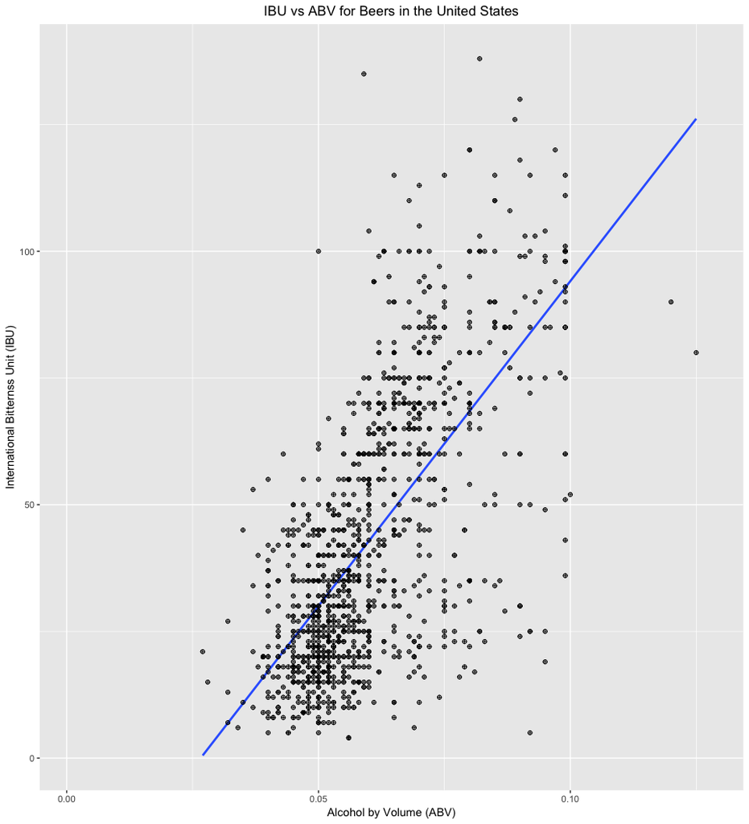

```r
ggplot(data=breweriesdf, aes(x=ABV, y=IBU)) +
  geom_smooth(method=lm, se=FALSE) +
  geom_point(mapping = , shape=10) +
  ggtitle("IBU vs ABV for Beers in the United States") +
  theme(plot.title=element_text(hjust=0.5)) +
  labs(x="Alcohol by Volume (ABV)", y="International Bitternss Unit (IBU)")
```

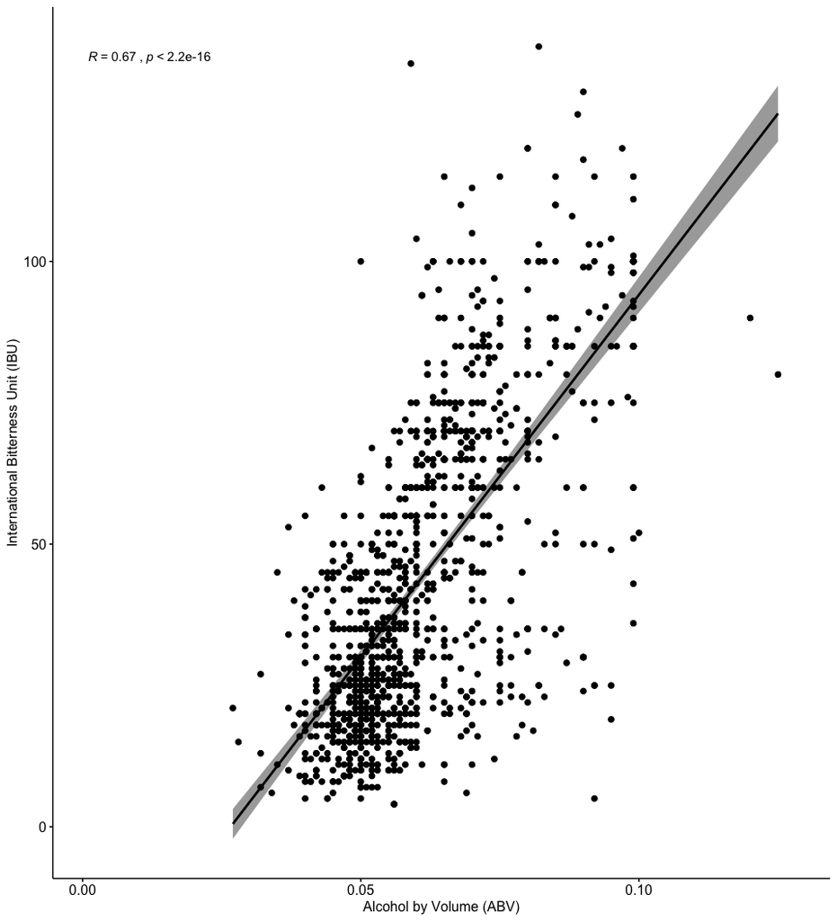

```r
library(ggpubr)
ggscatter(breweriesdf, x="ABV", y="IBU",
          add = "reg.line", conf.int=TRUE,
          cor.coef = TRUE, cor.method = "pearson",
          xlab = "Alcohol by Volume (ABV)", ylab = "International Bitterness Unit (IBU)")
```

```r
res <- cor.test(breweriesdf$ABV, breweriesdf$IBU, method="pearson")
res
```

```
##
##  Pearson's product-moment correlation
##
## data:  breweriesdf$ABV and breweriesdf$IBU
## t = 33.863, df = 1403, p-value < 2.2e-16
## alternative hypothesis: true correlation is not equal to 0
## 95 percent confidence interval:
##  0.6407982 0.6984238
## sample estimates:
##       cor
## 0.6706215
```

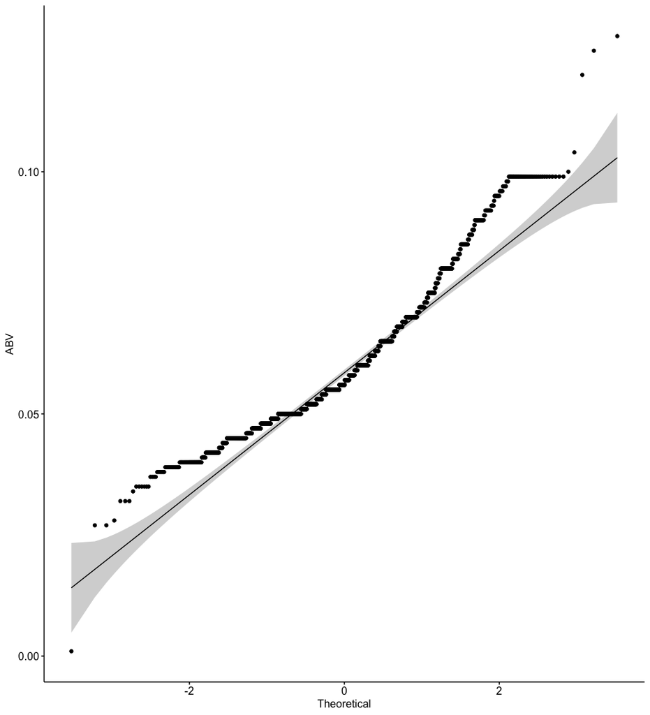

```r
ggqqplot(breweriesdf$ABV, ylab = "ABV")
```

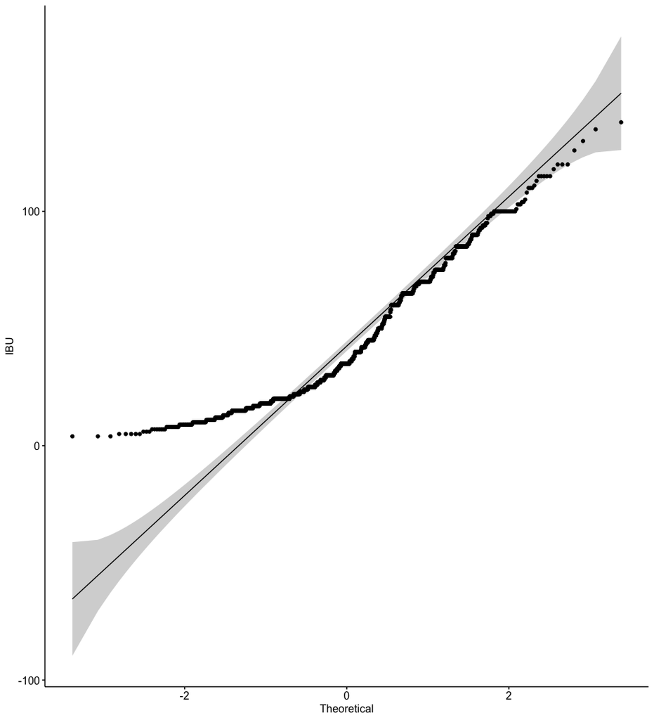

```r
ggqqplot(breweriesdf$IBU, ylab = "IBU")
```

# Conclusion

New Haven, Connecticut provides an ideal launch point for Blue Beer’s Expansion project. The median ABV and IBU for Connecticut match closely to Blue Beer’s Picasso’s. Connecticut has a low number, eight, of local breweries which makes breaking into the target market of iGen’s and Millennials advantageous over other states. A second test market is located in close proximity which is Baltimore, Maryland and provides a great follow-on expansion opportunity for Blue Beer’s Picasso before moving into the larger Indiana and Illinois markets. These test markets will be optimal for the future of mass production for Blue Beer’s Picasso nationwide.